# H3

The Artometrics of A YouTube Dynasty

Ethan Klein built one of YouTube’s most documented creator empires from a single channel and a lawsuit. H3h3Productions launched in 2011 as a reaction-commentary format, spent years as a meme factory, and then pivoted — twice — into something far more complicated. The H3 Podcast debuted in 2017. The Frenemies co-host era with Trisha Paytas ran for nine months in 2020–2021 and produced the highest viewership the show has ever seen. The Leftovers political co-host era with Hasan Piker ran until October 2023, when a public dispute over the Israel-Palestine conflict ended it. What remained after that is what this report analyzes: 1,638 videos across four channels, 680 podcast episodes, and three years of Reddit post data from the fan and critic communities that formed around the brand.

This is not a hit piece and it is not a fan report. It is a data report. The numbers are what they are.

## FAST FACTS

3.24B Total views across all four H3 channels, 2013–2026 — enough to give every person on Earth nearly half a view

1,638 Videos analyzed after filtering Shorts and zero-view uploads from the original 1,876-video pull

4.5× How much harder h3h3Productions hits per video vs. the H3 Podcast — 4.78M median vs. 1.05M

9 months The entire Frenemies Era — the most-watched stretch in H3 Podcast history, Sep 2020 to Jun 2021

## DATASET CONTEXT

The H3 ecosystem is not a single channel — it is a network. h3h3Productions launched in 2011 as a reaction-and-commentary channel built around the Fair Use legal fight that briefly made Ethan Klein a cause célèbre in YouTube creator circles. The H3 Podcast launched in 2017 as a separate channel and quickly became the brand’s primary vehicle. Hila Klein’s channel documents the Teddy Fresh clothing brand. The Ethan Klein channel captures solo content and live streams. This report analyzes all four: **1,638 videos** after filtering Shorts and zero-view uploads from the original 1,876-video pull via the YouTube Data API v3.

H3’s trajectory cannot be understood without the era framework. The podcast’s baseline (2017–2020) established the format: long-form conversation between Ethan and Hila, irregular cadence, modest but loyal viewership. The **Frenemies Era** (September 2020 – June 2021) is the single most-watched stretch in H3 Podcast history — nine months in which Ethan co-hosted with Trisha Paytas, generating a level of weekly engagement the show has never approached since. The **Leftovers Era** (September 2021 – October 2023) brought a political co-host in Hasan Piker, a different kind of audience, and a deeper ideological identity for the brand. When Leftovers ended over disagreements about the Israel-Palestine conflict, H3 entered its current post-format phase: fewer episodes, longer runtimes, a shrinking but committed core audience.

The core dataset was built from scratch using the YouTube Data API v3, stored at `github.com/Artometrics/h3`. Podcast episode metadata comes from the Podchaser API (680 episodes, April 2026 pull). Reddit post data was pulled from the Arctic Shift Reddit archive, covering **r/h3h3productions** (749,974 posts, 2014–2026) and **r/h3snark** (25,766 posts, April 2023–2026) — the fan sub and the critic sub, both active during the most contentious period in the brand’s history.

H3 is one of the most data-rich creator brands on the internet. The combination of YouTube longevity (13 years), a documented era structure, an unusually organized fan and critic community, and a clothing brand with its own Wikipedia page creates a dataset that rewards analysis. This report does not take a position on the controversies. It reads the numbers and describes what they show.

**SQL View filtering logic**

```
-- H3 Master Dataset: Filter and Prepare
-- Source: YouTube Data API v3 via Artometrics Original Pull
-- Mirrors: load-data and wrangle chunks in h3.qmd

SELECT
    channel,
    title,
    date,
    view_count,
    duration_minutes,
    DATE_TRUNC('month', date)  AS month_floor,
    DATE_TRUNC('year',  date)  AS year_floor,

    CASE
        WHEN date < '2020-09-15'                             THEN 'Podcast Launch'
        WHEN date BETWEEN '2020-09-15' AND '2021-06-08'     THEN 'Frenemies Era'
        WHEN date BETWEEN '2021-09-26' AND '2023-10-07'     THEN 'Leftovers Era'
        ELSE                                                      'Post-Leftovers'
    END AS era

FROM h3_master
WHERE duration_minutes > 1
  AND view_count       > 0
ORDER BY date ASC;


-- Reddit indexing query (mirrors Chart 3 construction)
WITH monthly_counts AS (
    SELECT
        source,
        DATE_TRUNC('month', date) AS month,
        COUNT(*)                  AS n_posts
    FROM (
        SELECT 'r/h3h3productions' AS source, date FROM h3_reddit_posts
        UNION ALL
        SELECT 'r/h3snark'        AS source, date FROM h3_snark_posts
    ) combined
    GROUP BY source, DATE_TRUNC('month', date)
),
subreddit_averages AS (
    SELECT source, AVG(n_posts) AS avg_posts
    FROM monthly_counts
    GROUP BY source
)
SELECT
    mc.source,
    mc.month,
    mc.n_posts,
    ROUND((mc.n_posts / sa.avg_posts) * 100, 1) AS index
FROM monthly_counts mc
JOIN subreddit_averages sa ON mc.source = sa.source
WHERE mc.month >= '2023-04-01'
ORDER BY mc.source, mc.month;
```

**Python View EDA notebook**

```
# H3 Artometrics — Python EDA
# Purpose: YouTube API pull structure + dataset diagnostics

import pandas as pd
import numpy as np
from googleapiclient.discovery import build

# ── 1. YouTube API Pull Structure ─────────────────────────────────────────────

CHANNEL_IDS = {
    "h3h3Productions": "UCDWIvJwLJsE4LG1Atne2blQ",
    "H3 Podcast":      "UCLtREklEc2upvIiudBMBmJg",
    "Hila Klein":      "UCgPTHMbDMCkDcGsZsKnJFGQ",
    "Ethan Klein":     "UCiDNNUJRqSHEtjGJO1m5mQA"
}
# API call pattern (executed separately, key stored in Google Cloud)
# youtube = build("youtube", "v3", developerKey=API_KEY)
# Results stored to data/h3_master.csv — 1,876 raw videos

# ── 2. Load Master Dataset ────────────────────────────────────────────────────

df = pd.read_csv("data/h3_master.csv", parse_dates=["date"])
df_clean = df[(df["duration_minutes"] > 1) & (df["view_count"] > 0)].copy()

print(f"Raw videos:    {len(df):,}")
print(f"After filter:  {len(df_clean):,}")
print(f"Dropped:       {len(df) - len(df_clean):,}")
# Raw: 1,876 | After filter: 1,638 | Dropped: 238

# ── 3. Channel Coverage ───────────────────────────────────────────────────────

channel_summary = (
    df_clean
    .groupby("channel")
    .agg(
        videos       = ("view_count", "count"),
        total_views  = ("view_count", "sum"),
        median_views = ("view_count", "median"),
        first_video  = ("date", "min"),
        last_video   = ("date", "max")
```

[output cut: 24 more lines]

```

eps = pd.read_csv("data/h3_podchaser_episodes.csv", parse_dates=["airDate"])
print(f"\nEpisodes total:   {len(eps):,}")
print(f"Date range:       {eps['airDate'].min().date()} → {eps['airDate'].max().date()}")
print(f"Median runtime:   {eps['length_min'].median():.0f} min")
print(f"Max runtime:      {eps['length_min'].max():.0f} min")
print(f"Missing duration: {eps['length_min'].isna().sum()} episodes")

# ── 6. Reddit Coverage Check ──────────────────────────────────────────────────

fans  = pd.read_csv("data/h3_reddit_posts.csv",  parse_dates=["date", "month"])
snark = pd.read_csv("data/h3_snark_posts.csv",   parse_dates=["date", "month"])

print(f"\nr/h3h3productions: {len(fans):,} posts | {fans['date'].min().date()} → {fans['date'].max().date()}")
print(f"r/h3snark:         {len(snark):,} posts | {snark['date'].min().date()} → {snark['date'].max().date()}")
```

## CHART 1 — THE ERA TIMELINE

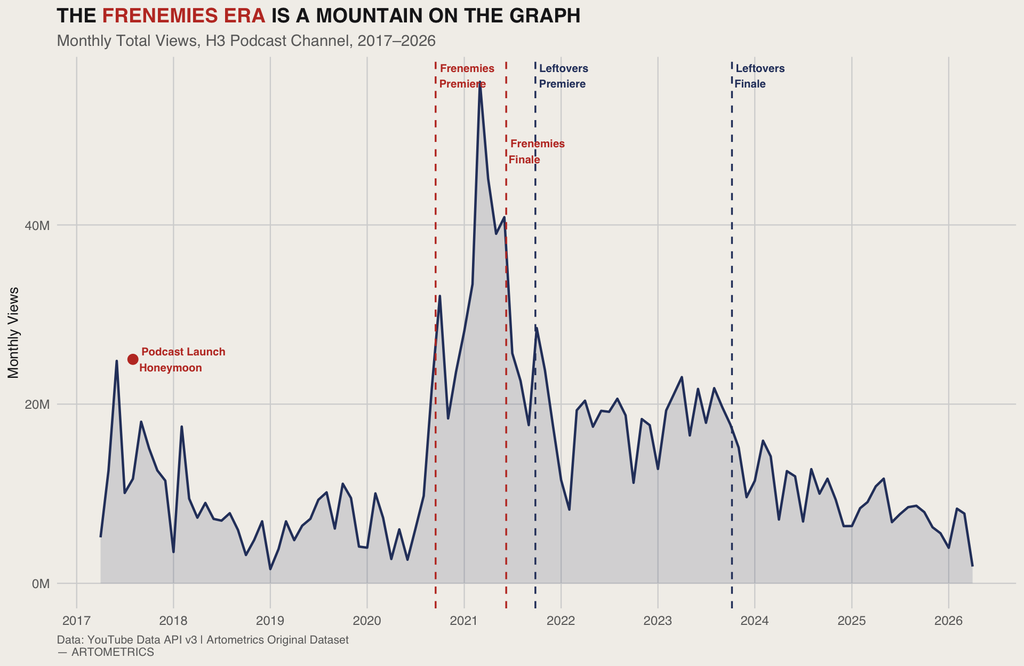

Even at its post-2023 lows, the H3 Podcast pulls millions of monthly views. The brand did not collapse — it contracted to its core. The audience that remains watches longer episodes with more commitment than the casual Frenemies-era viewer. The cliff looks dramatic on the chart because Frenemies was genuinely anomalous. The current numbers are not a failure; they are what a major podcast looks like without a viral co-host dynamic driving weekly drama.

**R View Chart 1 code**

```
era_lines <- data.frame(
  date  = as.Date(c("2020-09-15","2021-06-08","2021-09-26","2023-10-07")),
  label = c("Frenemies\nPremiere","Frenemies\nFinale",
            "Leftovers\nPremiere","Leftovers\nFinale"),
  color = c(art_highlight, art_highlight, art_secondary, art_secondary),
  vjust = c(1.3, 4.5, 1.3, 1.3)
)

p1 <- h3 |>
  filter(channel == "H3 Podcast") |>
  mutate(month_floor = floor_date(date, "month")) |>
  group_by(month_floor) |>
  summarise(monthly_views = sum(view_count, na.rm = TRUE)) |>
  ggplot(aes(x = month_floor, y = monthly_views)) +
  geom_area(fill = art_secondary, alpha = 0.15) +
  geom_line(color = art_secondary, linewidth = 0.8) +
  geom_vline(data = era_lines,
             aes(xintercept = date, color = color),
             linetype = "dashed", linewidth = 0.6) +
  geom_text(data = era_lines,
            aes(x = date, y = Inf, label = label, color = color, vjust = vjust),
            hjust = -0.08, size = 2.7, fontface = "bold") +
  scale_color_identity() +
  scale_y_continuous(labels = label_number(scale = 1e-6, suffix = "M")) +
  scale_x_date(date_breaks = "1 year", date_labels = "%Y") +
  labs(
    title   = "THE <span style='color:#C0392B'>**FRENEMIES ERA**</span> IS A MOUNTAIN ON THE GRAPH",
    subtitle = "Monthly Total Views, H3 Podcast Channel, 2017–2026",
    x = NULL, y = "Monthly Views",
    caption = "Data: YouTube Data API v3 | Artometrics Original Dataset\n— ARTOMETRICS"
  ) +
  theme_artometrics()

ggsave("chart1_era_timeline.png", plot = p1,
       path = "charts", width = 12, height = 7, dpi = 300, bg = "white")
```

## CHART 2 — THE DURATION DRIFT

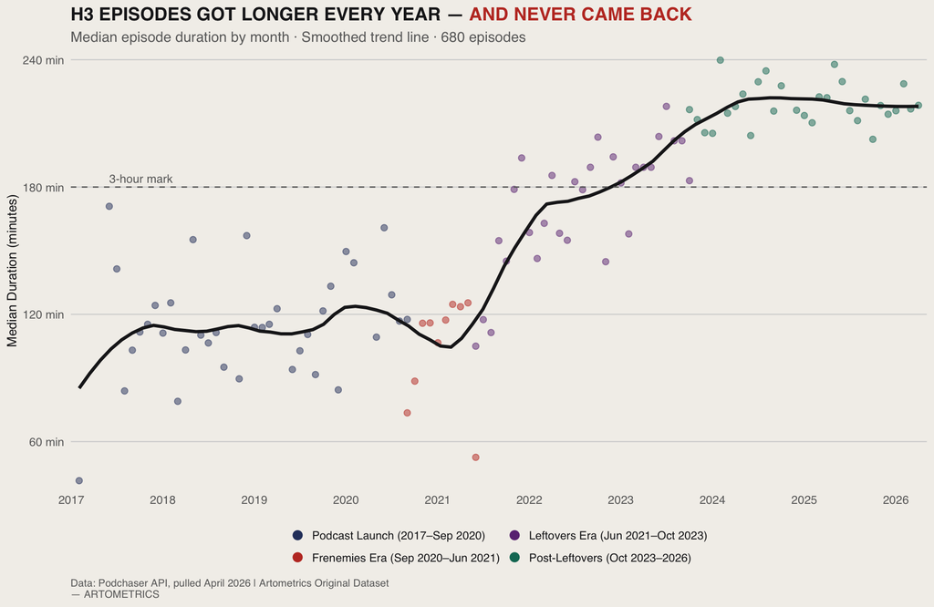

**R View Chart 2 code**

```
p2_data <- episodes |>
  mutate(
    airDate = as.Date(airDate),
    month   = floor_date(airDate, "month"),
    era     = case_when(
      airDate < as.Date("2020-09-15")                                    ~ "Podcast Launch (2017–Sep 2020)",
      airDate >= as.Date("2020-09-15") & airDate < as.Date("2021-06-08") ~ "Frenemies Era (Sep 2020–Jun 2021)",
      airDate >= as.Date("2021-06-08") & airDate < as.Date("2023-10-07") ~ "Leftovers Era (Jun 2021–Oct 2023)",
      TRUE                                                                ~ "Post-Leftovers (Oct 2023–2026)"
    ),
    era = factor(era, levels = era_levels_dur)
  ) |>
  group_by(month, era) |>
  summarise(median_min = median(length_min, na.rm = TRUE), .groups = "drop")

p2 <- ggplot(p2_data, aes(x = month, y = median_min)) +
  geom_point(aes(color = era), size = 2, alpha = 0.5) +
  geom_smooth(method = "loess", span = 0.25, se = FALSE,
              color = art_dark, linewidth = 1.2) +
  geom_hline(yintercept = 180, linetype = "dashed",
             color = art_mid, linewidth = 0.5) +
  scale_color_manual(values = era_colors_dur,
                     guide = guide_legend(nrow = 2)) +
  scale_x_date(date_breaks = "1 year", date_labels = "%Y") +
  scale_y_continuous(breaks = seq(0, 300, by = 60),
                     labels = function(x) paste0(x, " min")) +
  labs(
    title    = "H3 EPISODES GOT LONGER EVERY YEAR — <span style='color:#C0392B'>**AND NEVER CAME BACK**</span>",
    subtitle = "Median episode duration by month · Smoothed trend line · 680 episodes",
    x = NULL, y = "Median Duration (minutes)", color = NULL,
    caption = "Data: Podchaser API, pulled April 2026\n— ARTOMETRICS"
  ) +
  theme_artometrics() +
  theme(legend.position = "bottom", panel.grid.major.x = element_blank())

ggsave("chart2_duration_drift.png", plot = p2,
       path = "charts", width = 12, height = 7, dpi = 300, bg = "white")
```

## CHART 3 — THE FAN VS. CRITIC DIVIDE

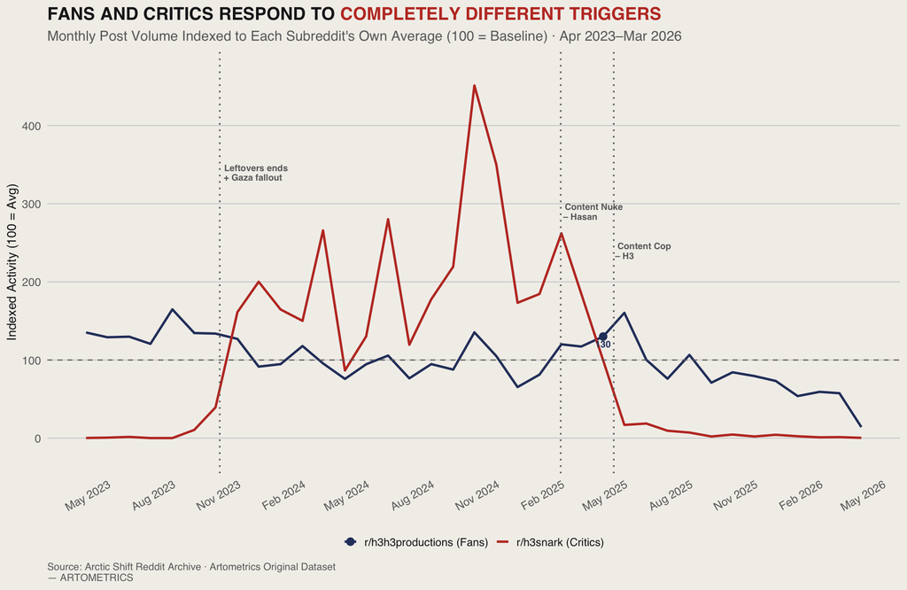

The cliff in the snark data after May 2025 isn’t a controversy dying down — it’s a subreddit going dark. After Klein issued copyright claims against r/h3snark moderators and threatened legal action, the sub announced an indefinite hiatus. The index collapsed to near zero within weeks. The fan sub, meanwhile, continued its slow decline — below its own average but still functional. The snark community didn’t fade. It was shut down. That distinction matters: one line represents organic audience erosion, the other represents a legal intervention.

**R View Chart 3 code**

```
window_start <- as.Date("2023-04-01")

fan_monthly   <- reddit |> filter(month >= window_start) |>
  count(month) |> mutate(source = "r/h3h3productions (Fans)")
snark_monthly <- snark  |> filter(month >= window_start) |>
  count(month) |> mutate(source = "r/h3snark (Critics)")

combined <- bind_rows(fan_monthly, snark_monthly) |>
  group_by(source) |>
  mutate(index = (n / mean(n, na.rm = TRUE)) * 100) |>
  ungroup()

p3 <- ggplot(combined, aes(x = month, y = index, color = source)) +
  geom_line(linewidth = 0.9) +
  geom_hline(yintercept = 100, linetype = "dashed",
             color = art_mid, linewidth = 0.4) +
  scale_color_manual(values = c(
    "r/h3h3productions (Fans)" = art_secondary,
    "r/h3snark (Critics)"      = art_highlight
  )) +
  scale_x_date(date_breaks = "3 months", date_labels = "%b %Y") +
  labs(
    title    = "FANS AND CRITICS RESPOND TO <span style='color:#C0392B'>**COMPLETELY DIFFERENT TRIGGERS**</span>",
    subtitle = "Monthly Post Volume Indexed to Each Subreddit's Own Average · Apr 2023–Mar 2026",
    x = NULL, y = "Indexed Activity (100 = Avg)", color = NULL,
    caption = "Source: Arctic Shift Reddit Archive\n— ARTOMETRICS"
  ) +
  theme_artometrics() +
  theme(legend.position = "bottom", panel.grid.major.x = element_blank(),
        axis.text.x = element_text(angle = 30, hjust = 1))

ggsave("chart3_reddit_activity.png", plot = p3,
       path = "charts", width = 12, height = 7, dpi = 300, bg = "white")
```

## LIMITATIONS

The YouTube data captures view counts as of the April 2026 pull — not at time of publication. Older videos have had years to accumulate views through algorithmic recommendations and search, which means early h3h3Productions videos are systematically over-represented in lifetime view totals relative to their original performance. The era-based analysis on the H3 Podcast channel is less affected because the comparison is within-channel across time.

The Arctic Shift Reddit archive is comprehensive but not guaranteed complete. Deleted posts, removed comments, and accounts banned before archival are absent from the dataset. The r/h3snark data begins in April 2023 — the sub’s founding — so pre-2023 critical community activity is unrepresented. Any conclusions about the fan-vs-critic dynamic are bounded by that window.

Episode duration data from Podchaser is self-reported by the show and may include inconsistencies for older episodes, live streams published as podcast episodes, and bonus or clip content. Episodes with missing duration values were excluded from Chart 2 analysis. Chart 3 indexes each subreddit to its own average across the Apr 2023–Mar 2026 window. A subreddit with low activity in early months will show inflated index values in later high-activity periods — the r/h3snark baseline is built on its full available history, which starts at launch and may slightly inflate peak readings relative to a steadier baseline.

## CONCLUSION

The H3 data tells a story about what happens when a creator brand builds its peak moment around someone else. The Frenemies Era was genuinely anomalous — nine months of co-host-driven drama that tripled the podcast’s monthly viewership and created a ceiling the show has never approached since. The chart is unambiguous about this. The current audience is not a collapse; it is a correction back to what the brand can sustain on its own terms.

The duration data adds a different dimension. The show that emerged from the Frenemies aftermath is structurally different from the one that preceded it — longer, less frequent, more demanding. Whether that format is a creative choice or a symptom of a contracting audience is a question the data cannot answer. Both explanations fit the numbers.

The Reddit chart is the most structurally interesting of the three. It documents not just audience behavior but audience management: a creator using legal tools to suppress a critic community. The snark subreddit’s cliff is not organic. It is the result of a deliberate intervention. The fan sub’s slower decline runs in parallel and suggests the underlying engagement problem would exist regardless. Two different communities, two different trajectories, one brand caught between them.

## REFERENCES

YouTube Data API v3. Google. https://developers.google.com/youtube/v3

Artometrics Original Dataset (April 2026). *H3 Podcast YouTube Network, 2013–2026*. Compiled via YouTube Data API v3. https://github.com/Artometrics/h3

Podchaser. (2026). *H3 Podcast episode data, 2017–2026*. Retrieved via Podchaser API v1. https://api.podchaser.com

Arctic Shift Reddit Archive. (2026). *r/h3h3productions and r/h3snark post data*. Retrieved April 2026. https://arctic-shift.photon-reddit.com

Wikimedia Foundation. (2026). *Wikipedia pageview statistics*. Retrieved via Wikimedia REST API. https://wikimedia.org/api/rest_v1/

Google Trends. (2026). *Search interest data: h3h3, ethan klein, frenemies, teddy fresh*. Retrieved via gtrendsR v1.5.2. https://trends.google.com

## EDITOR’S NOTE

This report was researched, written, designed, and produced in active collaboration with Claude AI (Anthropic). The data pipeline, statistical analysis, chart design, written analysis, narrative structure, and visual styling were all developed through a directed partnership between human editorial judgment and AI execution.

Artometrics was built on the premise that rigorous analysis and honest process are not in conflict. The research questions, editorial instincts, interpretive framing, and brand vision are ours. The execution — every line of R code, every paragraph of analysis, every design decision — was a collaboration. We document this not as a disclaimer but as a description of how we actually work, and as a position: we believe this is what serious data journalism looks like when the tools available are used honestly and at full capacity.

— Artometrics Editorial

[View on GitHub](https://github.com/Artometrics/h3)